# 第五章 离散时间傅里叶变换

## 混叠（Aliasing）

混叠会使频率发生“折叠”。

**输出频率 vs 输入频率关系图**

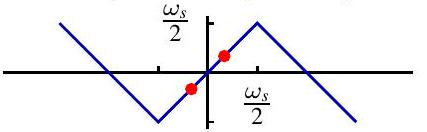

当 $\omega_0 < \omega_s/2$ 时，无混叠，重建信号与原始信号相同。

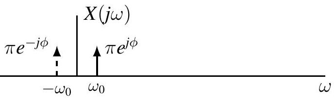

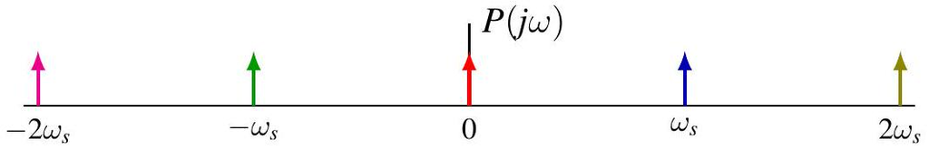

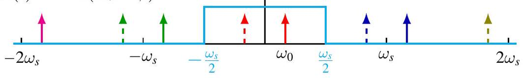

## 混叠（当输入频率高于奈奎斯特频率时）

当 $\omega_0 > \omega_s/2$ 时，发生混叠，重建信号频率变为 $\omega_s - \omega_0$，相位反转。

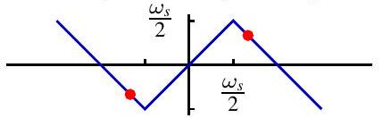

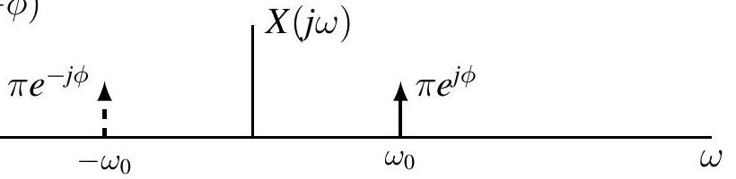

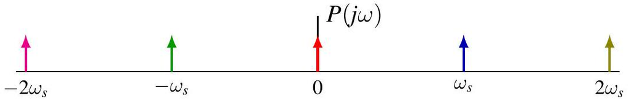

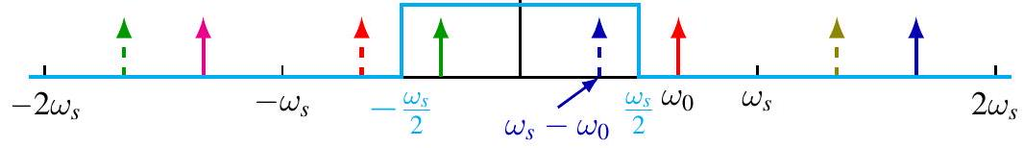

## 混叠示例

$x(t)=\cos(5\pi t/3)$ 采样后变为 $\cos(\pi n/3)$，重建后得到 $\cos(\pi t/3)$。

电影中车轮有时看起来慢速旋转甚至反向，就是混叠现象。

## 混叠边界情况（$\omega_0 = \omega_s/2$）

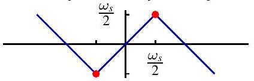

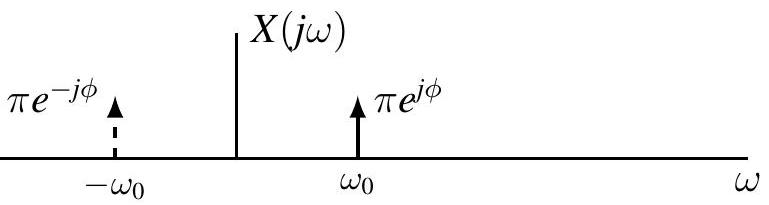

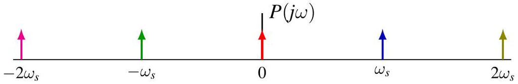

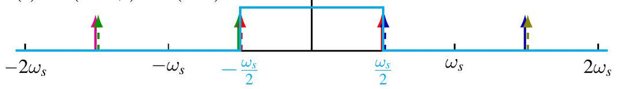

## 混叠对复杂信号的影响

混叠不仅影响单一频率，也会使复杂信号的频谱发生折叠。

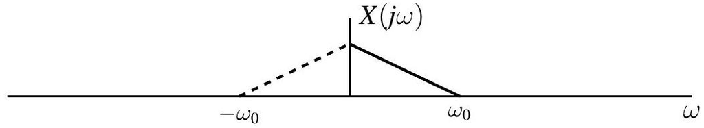

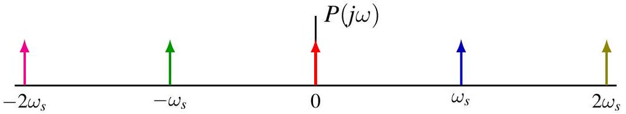

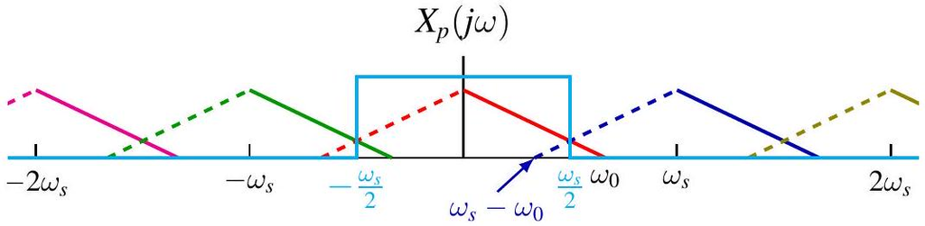

## 采样率越低，混叠越严重

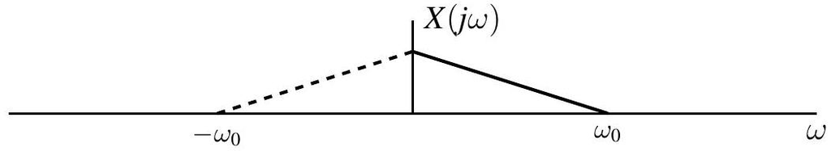

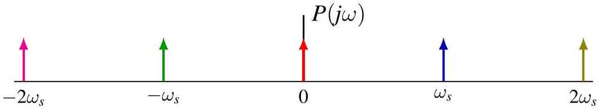

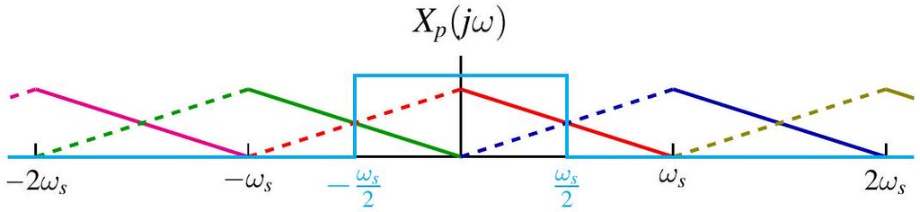

## 抗混叠滤波器

在采样前，用低通滤波器滤除高于 $\omega_s/2$ 的频率成分，可有效防止混叠。

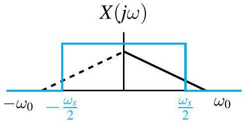

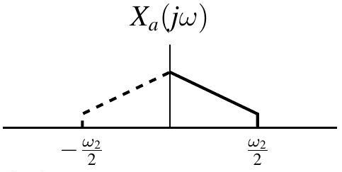

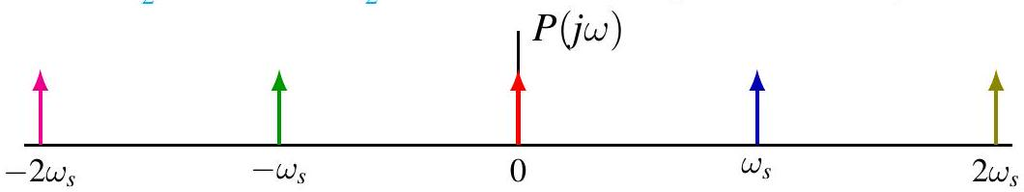

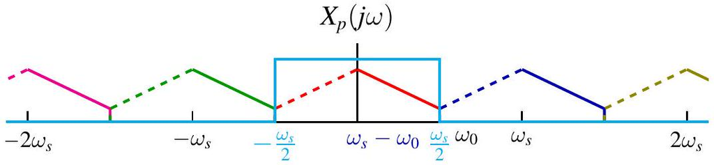

## 抗混叠滤波器（实际应用）

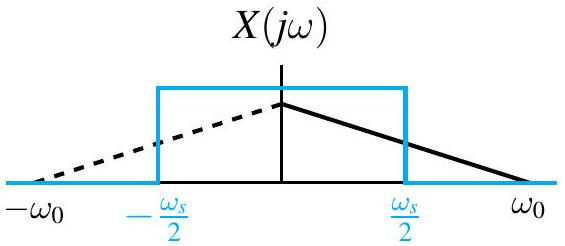

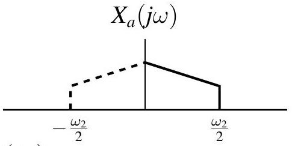

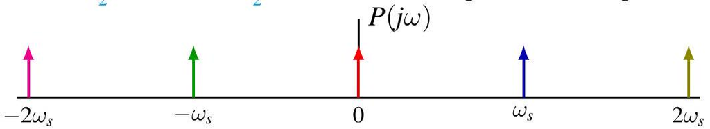

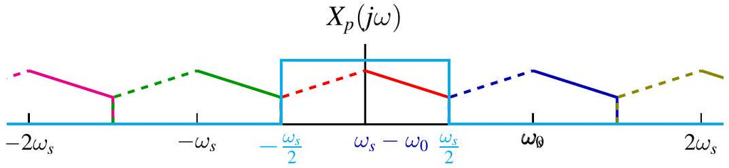

## DTFT 的卷积性质

$$(x * h)[n] \stackrel{\mathcal{F}}{\longleftrightarrow} X(e^{j\omega}) H(e^{j\omega})$$

## LTI 系统的频率响应

LTI 系统可由冲激响应 $h[n]$ 完全表征，也可由频率响应 $H(e^{j\omega})$ 表征（当其存在时）。

对于 BIBO 稳定系统，$h[n]\in\ell_1$。

利用卷积性质，可在频域中高效计算系统输出：
$$Y(e^{j\omega})=H(e^{j\omega})X(e^{j\omega})$$

## 示例1：两个指数信号

$h[n]=a^n u[n]$，$x[n]=b^n u[n]$（$|a|<1,|b|<1$）

使用 DTFT 求解输出 $y[n]$，包括 $a=b$ 时的特殊情况（利用微分性质）。

## 示例2：余弦信号输入

$x[n]=\cos(\omega_0 n)$，系统频率响应 $H(e^{j\omega})=1/(1-a e^{-j\omega})$

输出为幅度和相位调整后的同频率余弦信号。

## DTFT 的乘积性质

$$x[n]y[n] \stackrel{\mathcal{F}}{\longleftrightarrow} \frac{1}{2\pi} X \circledast Y = \frac{1}{2\pi}\int_{2\pi} X(e^{j\theta})Y(e^{j(\omega-\theta)})d\theta$$

## 示例：两个sinc函数相乘

$x_1[n]=\sin(3\pi n/4)/(\pi n)$，$x_2[n]=\sin(\pi n/2)/(\pi n)$

## 示例：离散时间调制

$y[n]=x[n]\cos(\omega_c n)$

无重叠条件：$\omega_c > \omega_M$ 且 $\omega_c + \omega_M < \pi$

## 示例：离散时间解调

$z[n]=y[n]\cos(\omega_c n)$，再通过合适截止频率的低通滤波恢复原始信号。

## 线性常系数差分方程描述的系统

差分方程：
$$\sum_{k=0}^N a_k y[n-k] = \sum_{k=0}^M b_k x[n-k]$$

频率响应：
$$H(e^{j\omega})=\frac{\sum b_k e^{-j\omega k}}{\sum a_k e^{-j\omega k}}$$

两种求法：特征函数代入法 或 直接对差分方程两边取 DTFT。

## 示例：具体二阶系统

$y[n] - (3/4)y[n-1] + (1/8)y[n-2] = 2x[n]$

求出 $H(e^{j\omega})$，通过部分分式展开得到 $h[n]$。

## 示例：求零状态响应

输入 $x[n]=(1/4)^n u[n]$，使用部分分式展开求 $y[n]$（含重根情况）。

## 部分分式展开方法（离散时间特有）

用 $z$ 替换 $e^{-j\omega}$，求留数。对于重根，使用导数法求系数。

## 逆 DTFT 常用变换对（含重极点）

$$\binom{n+m-1}{n} a^n u[n] \stackrel{\mathcal{F}}{\longleftrightarrow} \frac{1}{(1-a e^{-j\omega})^m},\quad |a|<1$$

## 离散时间信号的冲激列采样

$p[n]=\sum \delta[n-kN]$

采样信号 $x_p[n]=x[n]p[n]$

频谱：
$$X_p(e^{j\omega})=\frac{1}{N}\sum_{k=0}^{N-1} X(e^{j(\omega - k\cdot 2\pi/N)})$$

## 离散时间采样定理

带限 DT 信号（$X(e^{j\omega})=0$ 当 $\omega_M < |\omega|\leq\pi$），若 $\omega_s=2\pi/N > 2\omega_M$，则可由子序列 $x[kN]$ 唯一恢复。

重建使用增益为 $N$ 的低通滤波器 + sinc 插值。

## 抽取（Decimation）

$x_b[n]=x[nN]$

频域关系：$X_b(e^{j\omega})=X_p(e^{j\omega/N})$（频谱拉伸）

## 连续时间信号的离散时间处理

整体流程：C/D（模数转换）→ 离散时间处理 → D/C（数模转换）

优点：数字设备灵活性高、抗噪声能力强。

理想假设：无量化、理想冲激采样、理想重建。

## 模数转换（C/D）

时域与频域关系：
$$X_p(j\omega)=X_d(e^{j\omega T})$$

## 数模转换（D/C）

反向过程，低通滤波器截止在 $\omega_s/2$。

## 整体频率响应

$$H_c(j\omega)=\begin{cases}H_d(e^{j\omega T}) & |\omega|<\omega_s/2 \\ 0 & \text{其他}\end{cases}$$

## 作业

[output not shown]